# Time series classification

```r
sales <- read.csv("C:/Users/Akhilesh/Downloads/BoC/sales_data_sample.csv")
str(sales)
```

```
## 'data.frame':    2823 obs. of  25 variables:
##  $ ORDERNUMBER     : int  10107 10121 10134 10145 10159 10168 10180 10188 10201 10211 ...
##  $ QUANTITYORDERED : int  30 34 41 45 49 36 29 48 22 41 ...
##  $ PRICEEACH       : num  95.7 81.3 94.7 83.3 100 ...
##  $ ORDERLINENUMBER : int  2 5 2 6 14 1 9 1 2 14 ...
##  $ SALES           : num  2871 2766 3884 3747 5205 ...
##  $ ORDERDATE       : Factor w/ 252 levels "1/10/2003 0:00",..: 113 186 205 227 24 40 49 57 83 5 ...
##  $ STATUS          : Factor w/ 6 levels "Cancelled","Disputed",..: 6 6 6 6 6 6 6 6 6 6 ...
##  $ QTR_ID          : int  1 2 3 3 4 4 4 4 4 1 ...
##  $ MONTH_ID        : int  2 5 7 8 10 10 11 11 12 1 ...
##  $ YEAR_ID         : int  2003 2003 2003 2003 2003 2003 2003 2003 2003 2004 ...
##  $ PRODUCTLINE     : Factor w/ 7 levels "Classic Cars",..: 2 2 2 2 2 2 2 2 2 2 ...
##  $ MSRP            : int  95 95 95 95 95 95 95 95 95 95 ...
##  $ PRODUCTCODE     : Factor w/ 109 levels "S10_1678","S10_1949",..: 1 1 1 1 1 1 1 1 1 1 ...
##  $ CUSTOMERNAME    : Factor w/ 92 levels "Alpha Cognac",..: 47 68 48 87 24 81 27 42 58 10 ...
##  $ PHONE           : Factor w/ 91 levels "(02) 5554 67",..: 49 55 17 77 78 80 41 22 79 4 ...
##  $ ADDRESSLINE1    : Factor w/ 92 levels "?kergatan 24",..: 59 42 23 56 53 60 9 69 39 19 ...
##  $ ADDRESSLINE2    : Factor w/ 10 levels "","2nd Floor",..: 1 1 1 1 1 1 1 1 1 1 ...
##  $ CITY            : Factor w/ 73 levels "Aaarhus","Allentown",..: 49 57 53 54 60 13 29 5 60 53 ...
##  $ STATE           : Factor w/ 17 levels "","BC","CA","CT",..: 11 1 1 3 3 3 1 1 3 1 ...
##  $ POSTALCODE      : Factor w/ 74 levels "","10022","10100",..: 2 29 43 51 1 56 33 66 1 42 ...
##  $ COUNTRY         : Factor w/ 19 levels "Australia","Austria",..: 19 7 7 19 19 19 7 12 19 7 ...
##  $ TERRITORY       : Factor w/ 3 levels "APAC","EMEA",..: NA 2 2 NA NA NA 2 2 NA 2 ...
##  $ CONTACTLASTNAME : Factor w/ 77 levels "Accorti","Ashworth",..: 77 29 18 76 9 31 58 53 49 54 ...
##  $ CONTACTFIRSTNAME: Factor w/ 72 levels "Adrian","Akiko",..: 37 55 12 32 32 33 45 66 32 15 ...
##  $ DEALSIZE        : Factor w/ 3 levels "Large","Medium",..: 3 3 2 2 2 2 3 2 3 2 ...
```

```r
sum(is.na(sales))
```

```
## [1] 1074
```

```r
nrow(sales)
```

```
## [1] 2823
```

```r
list.NA<-""
for (i in c(1:ncol(sales)))
{
  len<-length(grep("TRUE",is.na(sales[,i])))
  if(len > 0){
    list.NA<-paste(colnames(sales[i]),":",len,list.NA)
  }
}
list.NA
```

```
## [1] "TERRITORY : 1074 "
```

We can see that more than 30% of the data in territory is having the missing values. Lets try to impute the missing values using MICE and KNN methods.

```r
#if (!(require(Hmisc))) {install.packages("Hmisc")};
library(Hmisc)
library(VIM)
library(mice)
library(magrittr)
```

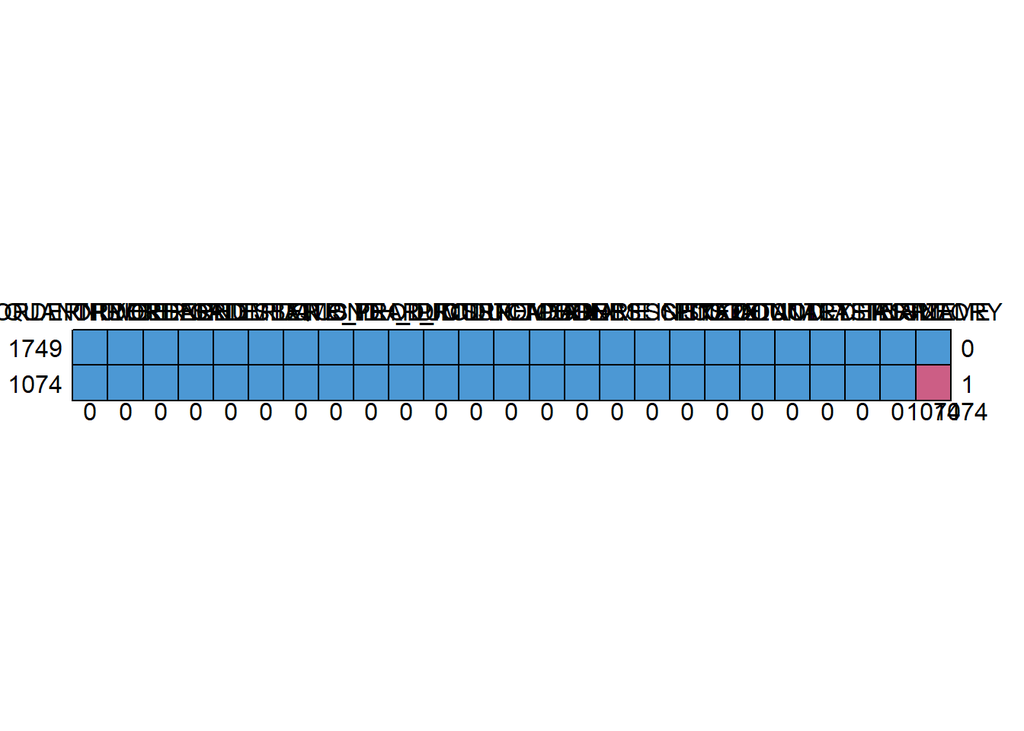

```
##      ORDERNUMBER QUANTITYORDERED PRICEEACH ORDERLINENUMBER SALES ORDERDATE
## 1749           1               1         1               1     1         1
## 1074           1               1         1               1     1         1
##                0               0         0               0     0         0
##      STATUS QTR_ID MONTH_ID YEAR_ID PRODUCTLINE MSRP PRODUCTCODE
## 1749      1      1        1       1           1    1           1
## 1074      1      1        1       1           1    1           1
##           0      0        0       0           0    0           0
##      CUSTOMERNAME PHONE ADDRESSLINE1 ADDRESSLINE2 CITY STATE POSTALCODE
## 1749            1     1            1            1    1     1          1
## 1074            1     1            1            1    1     1          1
##                 0     0            0            0    0     0          0
##      COUNTRY CONTACTLASTNAME CONTACTFIRSTNAME DEALSIZE TERRITORY
## 1749       1               1                1        1         1    0
## 1074       1               1                1        1         0    1
##            0               0                0        0      1074 1074
```

```r
md.pattern(sales)
```

From the above plot we can see that their is so many missing values in Territory.Lets impute them.

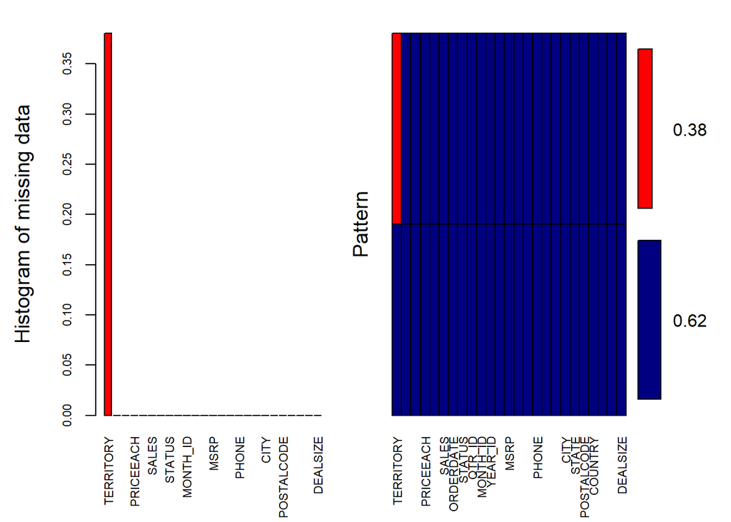

```
##
##  Variables sorted by number of missings:
##          Variable     Count
##         TERRITORY 0.3804463
##       ORDERNUMBER 0.0000000
##   QUANTITYORDERED 0.0000000
##         PRICEEACH 0.0000000
##   ORDERLINENUMBER 0.0000000
##             SALES 0.0000000
##         ORDERDATE 0.0000000
##            STATUS 0.0000000
##            QTR_ID 0.0000000
##          MONTH_ID 0.0000000
##           YEAR_ID 0.0000000
##       PRODUCTLINE 0.0000000
##              MSRP 0.0000000
##       PRODUCTCODE 0.0000000
##      CUSTOMERNAME 0.0000000
##             PHONE 0.0000000
##      ADDRESSLINE1 0.0000000
##      ADDRESSLINE2 0.0000000
##              CITY 0.0000000
##             STATE 0.0000000
##        POSTALCODE 0.0000000
##           COUNTRY 0.0000000
##   CONTACTLASTNAME 0.0000000
##  CONTACTFIRSTNAME 0.0000000
##          DEALSIZE 0.0000000
```

```r
library(VIM)
aggr_plot <- aggr(sales,

        # display parms
        col=c('navyblue','red'), numbers=TRUE, sortVars=TRUE, labels=names(sales),

        # graphical parms
        cex.axis=.7, gap=3, ylab=c("Histogram of missing data","Pattern"))
```

```r
sales_1 = kNN(sales, variable = c("TERRITORY"))
```

```r
list.NA<-""
for (i in c(1:ncol(sales_1)))
{
  len<-length(grep("TRUE",is.na(sales_1[,i])))
  if(len > 0){
    list.NA<-paste(colnames(sales_1[i]),":",len,list.NA)
  }
}
list.NA
```

```
## [1] ""
```

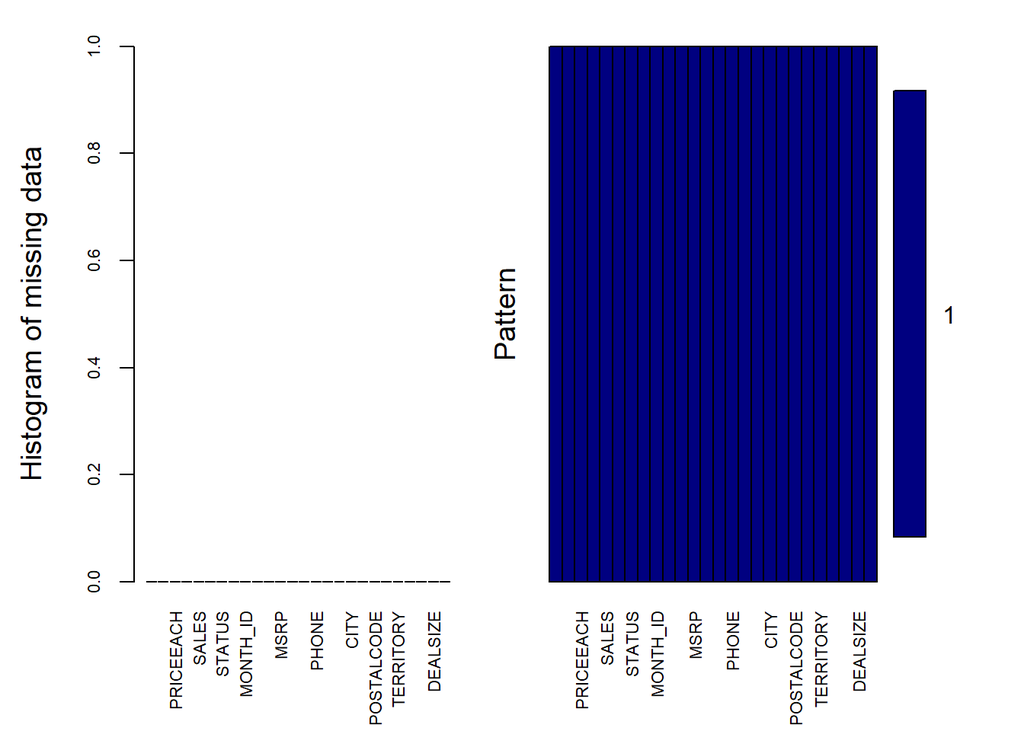

```
##
##  Variables sorted by number of missings:
##          Variable Count
##       ORDERNUMBER     0
##   QUANTITYORDERED     0
##         PRICEEACH     0
##   ORDERLINENUMBER     0
##             SALES     0
##         ORDERDATE     0
##            STATUS     0
##            QTR_ID     0
##          MONTH_ID     0
##           YEAR_ID     0
##       PRODUCTLINE     0
##              MSRP     0
##       PRODUCTCODE     0
##      CUSTOMERNAME     0
##             PHONE     0
##      ADDRESSLINE1     0
##      ADDRESSLINE2     0
##              CITY     0
##             STATE     0
##        POSTALCODE     0
##           COUNTRY     0
##         TERRITORY     0
##   CONTACTLASTNAME     0
##  CONTACTFIRSTNAME     0
##          DEALSIZE     0
##       ORDERNUMBER     0
```

```r
aggr_plot <- aggr(sales_1,

        # display parms
        col=c('navyblue','red'), numbers=TRUE, sortVars=TRUE, labels=names(sales),

        # graphical parms
        cex.axis=.7, gap=3, ylab=c("Histogram of missing data","Pattern"))
```

From the above plot we can see that there is no missing values. All are imputed.

```r
str(sales_1)
```

```
## 'data.frame':    2823 obs. of  26 variables:
##  $ ORDERNUMBER     : int  10107 10121 10134 10145 10159 10168 10180 10188 10201 10211 ...
##  $ QUANTITYORDERED : int  30 34 41 45 49 36 29 48 22 41 ...
##  $ PRICEEACH       : num  95.7 81.3 94.7 83.3 100 ...
##  $ ORDERLINENUMBER : int  2 5 2 6 14 1 9 1 2 14 ...
##  $ SALES           : num  2871 2766 3884 3747 5205 ...
##  $ ORDERDATE       : Factor w/ 252 levels "1/10/2003 0:00",..: 113 186 205 227 24 40 49 57 83 5 ...
##  $ STATUS          : Factor w/ 6 levels "Cancelled","Disputed",..: 6 6 6 6 6 6 6 6 6 6 ...
##  $ QTR_ID          : int  1 2 3 3 4 4 4 4 4 1 ...
##  $ MONTH_ID        : int  2 5 7 8 10 10 11 11 12 1 ...
##  $ YEAR_ID         : int  2003 2003 2003 2003 2003 2003 2003 2003 2003 2004 ...
##  $ PRODUCTLINE     : Factor w/ 7 levels "Classic Cars",..: 2 2 2 2 2 2 2 2 2 2 ...
##  $ MSRP            : int  95 95 95 95 95 95 95 95 95 95 ...
##  $ PRODUCTCODE     : Factor w/ 109 levels "S10_1678","S10_1949",..: 1 1 1 1 1 1 1 1 1 1 ...
##  $ CUSTOMERNAME    : Factor w/ 92 levels "Alpha Cognac",..: 47 68 48 87 24 81 27 42 58 10 ...
##  $ PHONE           : Factor w/ 91 levels "(02) 5554 67",..: 49 55 17 77 78 80 41 22 79 4 ...
##  $ ADDRESSLINE1    : Factor w/ 92 levels "?kergatan 24",..: 59 42 23 56 53 60 9 69 39 19 ...
##  $ ADDRESSLINE2    : Factor w/ 10 levels "","2nd Floor",..: 1 1 1 1 1 1 1 1 1 1 ...
##  $ CITY            : Factor w/ 73 levels "Aaarhus","Allentown",..: 49 57 53 54 60 13 29 5 60 53 ...
##  $ STATE           : Factor w/ 17 levels "","BC","CA","CT",..: 11 1 1 3 3 3 1 1 3 1 ...
##  $ POSTALCODE      : Factor w/ 74 levels "","10022","10100",..: 2 29 43 51 1 56 33 66 1 42 ...
##  $ COUNTRY         : Factor w/ 19 levels "Australia","Austria",..: 19 7 7 19 19 19 7 12 19 7 ...
##  $ TERRITORY       : Factor w/ 3 levels "APAC","EMEA",..: 2 2 2 2 2 2 2 2 2 2 ...
##  $ CONTACTLASTNAME : Factor w/ 77 levels "Accorti","Ashworth",..: 77 29 18 76 9 31 58 53 49 54 ...
##  $ CONTACTFIRSTNAME: Factor w/ 72 levels "Adrian","Akiko",..: 37 55 12 32 32 33 45 66 32 15 ...
##  $ DEALSIZE        : Factor w/ 3 levels "Large","Medium",..: 3 3 2 2 2 2 3 2 3 2 ...
##  $ TERRITORY_imp   : logi  TRUE FALSE FALSE TRUE TRUE TRUE ...
```

```r
unique(sales_1$YEAR_ID)
```

```
## [1] 2003 2004 2005
```

```r
unique(sales_1$MONTH_ID)
```

```
##  [1]  2  5  7  8 10 11 12  1  4  6  9  3
```

```r
unique(sales_1$QTR_ID)
```

```
## [1] 1 2 3 4
```

```r
unique(sales_1$STATUS)
```

```
## [1] Shipped    Disputed   In Process Cancelled  On Hold    Resolved
## Levels: Cancelled Disputed In Process On Hold Resolved Shipped
```

```r
unique(sales_1$CITY)
```

```
##  [1] NYC            Reims          Paris          Pasadena
##  [5] San Francisco  Burlingame     Lille          Bergen
##  [9] Melbourne      Newark         Bridgewater    Nantes
## [13] Cambridge      Helsinki       Stavern        Allentown
## [17] Salzburg       Chatswood      New Bedford    Liverpool
## [21] Madrid         Lule           Singapore      South Brisbane
## [25] Philadelphia   Lyon           Vancouver      Burbank
## [29] New Haven      Minato-ku      Torino         Boras
## [33] Versailles     San Rafael     Nashua         Brickhaven
## [37] North Sydney   Montreal       Osaka          White Plains
## [41] Kobenhavn      London         Toulouse       Barcelona
## [45] Los Angeles    San Diego      Bruxelles      Tsawassen
## [49] Boston         Cowes          Oulu           San Jose
## [53] Graz           Makati City    Marseille      Koln
## [57] Gensve         Reggio Emilia  Frankfurt      Espoo
## [61] Dublin         Manchester     Aaarhus        Glendale
## [65] Sevilla        Brisbane       Strasbourg     Las Vegas
## [69] Oslo           Bergamo        Glen Waverly   Munich
## [73] Charleroi
## 73 Levels: Aaarhus Allentown Barcelona Bergamo Bergen Boras ... White Plains
```

```r
unique(sales_1$COUNTRY)
```

```
##  [1] USA         France      Norway      Australia   Finland
##  [6] Austria     UK          Spain       Sweden      Singapore
## [11] Canada      Japan       Italy       Denmark     Belgium
## [16] Philippines Germany     Switzerland Ireland
## 19 Levels: Australia Austria Belgium Canada Denmark Finland ... USA
```